# Study Case II : Customer Response Prediction and Profit Optimization

Avant d’attaquer le coeur du sujet, importons librairies et les paquets nécessaires que nous allons utiliser au cours de cette étude de cas.

```r
library(party)
library(Metrics)
```

## Data and Variables

Commençons par importer le fichier d’apprentissage.

```r
cup98lrn <- read.csv(file='cup98LRN.txt', header=TRUE, sep=',')

cup98lrn_rows <- nrow(cup98lrn)
```

## Data Exploration

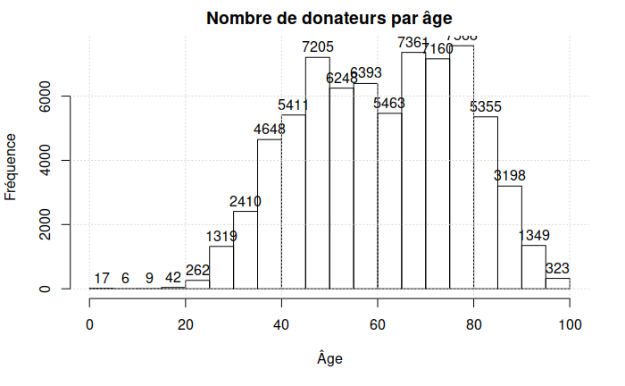

```r
hist(cup98lrn$AGE, main='Nombre de donateurs par âge',
     xlab='Âge', ylab='Fréquence', labels=TRUE)
grid()
```

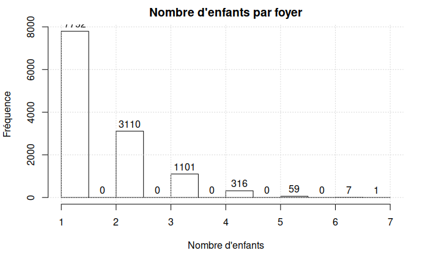

```r
hist(cup98lrn$NUMCHLD, right=FALSE, main='Nombre d\'enfants par foyer',
     xlab='Nombre d\'enfants', ylab='Fréquence', labels=TRUE)
grid()
```

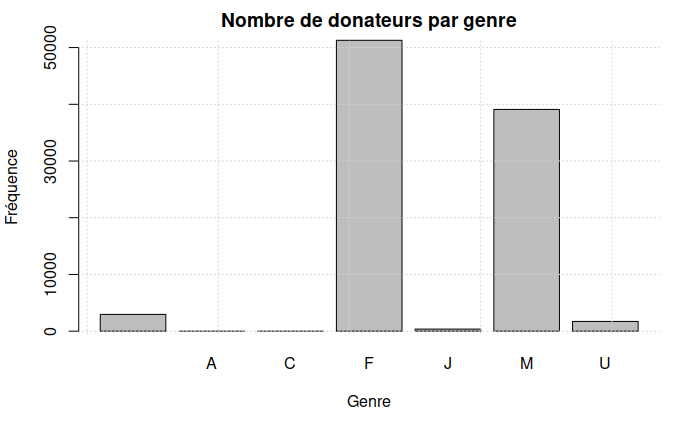

```r
plot(cup98lrn$GENDER, main='Nombre de donateurs par genre',
     xlab='Genre', ylab='Fréquence')
grid()
```

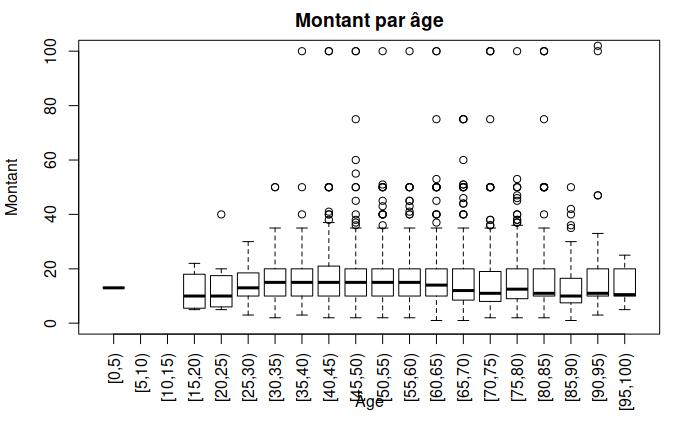

```r
pos_cup98lrn <- cup98lrn[cup98lrn$TARGET_D>0,]

boxplot(pos_cup98lrn$TARGET_D ~ cut(pos_cup98lrn$AGE, right=FALSE, breaks=seq(0,100,5)), main='Montant par âge',
        xlab='Âge', ylab='Montant', ylim=c(0,100), las=3)
```

```r
plot(density(pos_cup98lrn$TARGET_D[pos_cup98lrn$GENDER=='M']), main='Probabilité des dons par montant',
     xlab='Montant', ylab='Probabilité', col='blue', xlim=c(0,100))

lines(density(pos_cup98lrn$TARGET_D[pos_cup98lrn$GENDER=='F']), col='red')
```

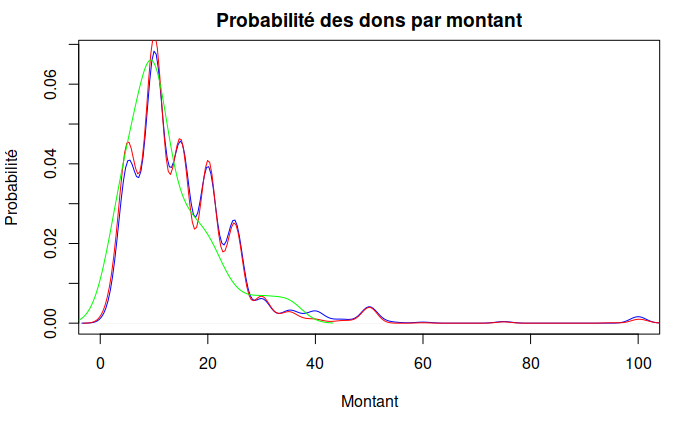

```r
lines(density(pos_cup98lrn$TARGET_D[pos_cup98lrn$GENDER=='J']), col='green')
```

## Training Decision Trees

Prenons une seed, afin que nos résultats soient reproductibles.

```r
set.seed(1234)
```

Sélectionnons maintenant les données avec lesquelles nous construirons nos arbres de décisions.

```r
relevant_col_cup98lrn <- c('AGE', 'AVGGIFT', 'CARDGIFT', 'CARDPM12', 'CARDPROM', 'CLUSTER', 'CLUSTER2', 'DOMAIN', 'GENDER', 'GEOCODE2', 'HIT', 'HOMEOWNR', 'HPHONE_D', 'INCOME', 'LASTGIFT', 'MAXRAMNT', 'MDMAUD_A', 'MDMAUD_F', 'MDMAUD_R', 'MINRAMNT', 'NGIFTALL', 'NUMCHLD', 'NUMPRM12', 'PCOWNERS', 'PEPSTRFL', 'PETS', 'RAMNTALL', 'RECINHSE', 'RFA_2A', 'RFA_2F', 'STATE', 'TIMELAG')

cup98lrn <- cup98lrn[c('TARGET_D', relevant_col_cup98lrn)]
```

Pour nous faciliter la vie plus tard, nous allons créer une fonction `new_tree` qui crée et entraîne un arbre en fonction de certains paramètres. La fonction sauvegardera aussi l’arbre et les cumuls des donations des runs avec leur moyenne. Elle renverra ce dernier sous forme de dataframe afin de pouvoir exploiter les données directement. Elle pourra également faire des affichages mais ceux-ci sont en commentaire si vous voulez les voir.

```r
new_tree <- function(loops, rate, cup98_filtered, minsplit, minbucket, maxsurrogate, maxdepth) {
        addup_donations_rows <- round(cup98lrn_rows*(1-rate))
        addup_donations <- matrix(0, nrow=addup_donations_rows, ncol=loops)

        for(i in 1:loops) {
                # on répartit nos données en un set d'entraînement et un set de test
                ind <- sample(cup98lrn_rows, size=cup98lrn_rows-addup_donations_rows)
                X_train = cup98_filtered[ ind,]
                X_test  = cup98_filtered[-ind,]

                # on entraîne un arbre de décision et on le save dans le répertoire courant
                new_ctree <- ctree(TARGET_D ~ ., X_train, controls=ctree_control(minsplit=minsplit, minbucket=minbucket, maxsurrogate=maxsurrogate, maxdepth=maxdepth))
                save(new_ctree, file=paste('new_ctree -', minsplit, '-', minbucket, '-', maxsurrogate, '-', maxdepth, '- run', i, '.rdata'))
                # plot(new_ctree)

                # on prédit les données de test
                # on les trie par ordre décroissant pour plus de clarté
                pred <- predict(new_ctree, newdata=X_test)
                pred.index.decr <- sort(pred, decreasing=TRUE, method='quick', index.return=TRUE)$ix
                # plot(pred)

                # on met à jour nos matrices de donations
                addup_donations[, i] <- cumsum(X_test$TARGET_D[pred.index.decr])
        }

        # on fusionne les cumuls des donations nos runs avec la moyenne de chaque don en un dataframe
        results <- data.frame(cbind(addup_donations, rowMeans(addup_donations)))
        names(results) <- c(paste('run', 1:loops), 'average')

        # on enregistre nos résultats dans un fichier csv
        write.csv(results, paste('addup_donations -', minsplit, '-', minbucket, '-', maxsurrogate, '-', maxdepth, '.csv'))

        # on retourne les résultats afin de les rendre utilisable directement
        return(results)
}
```

Maintenant que la fonction est créée, on peut l’appeler et sauvegarder les résultats afin de les réutiliser directement. Appelons-la avec minsplit=1000, minbucket=400, maxsurrogate=4 et maxdepth=10. On fera 10 boucles et on prendra 30% des données pertinentes de cup98 comme ensemble de test.

```r
results <- new_tree(10, 0.7, cup98lrn, 1000, 400, 4, 10)
```

## Model Evaluation

Précédemment, nous n’avons pas tenu compte du coût de contacter chaque potentiel donateur. C’est ici que l’on va le prendre en compte, ce qui va certes réduire le profit mais également nous donner un résultat plus réaliste.

```r
cost <- 0.5
loops <- 10
results_rows <- nrow(results)

tail(results) # avant de tenir compte du coût
```

|  | run 1 | run 2 | run 3 | run 4 | run 5 | run 6 | run 7 | run 8 | run 9 | run 10 | average |
| --- | --- | --- | --- | --- | --- | --- | --- | --- | --- | --- | --- |
| 28619 | 22966.67 | 21644.46 | 22915.08 | 21351.87 | 22484.96 | 22819.2 | 22672.75 | 22868.13 | 22573 | 22552.7 | 22484.88 |
| 28620 | 22966.67 | 21644.46 | 22915.08 | 21351.87 | 22484.96 | 22819.2 | 22672.75 | 22868.13 | 22573 | 22552.7 | 22484.88 |
| 28621 | 22981.67 | 21644.46 | 22915.08 | 21351.87 | 22484.96 | 22819.2 | 22692.75 | 22868.13 | 22573 | 22552.7 | 22488.38 |
| 28622 | 22981.67 | 21644.46 | 22915.08 | 21351.87 | 22484.96 | 22819.2 | 22692.75 | 22878.13 | 22573 | 22552.7 | 22489.38 |
| 28623 | 22981.67 | 21644.46 | 22915.08 | 21351.87 | 22494.96 | 22819.2 | 22692.75 | 22878.13 | 22573 | 22552.7 | 22490.38 |
| 28624 | 22981.67 | 21644.46 | 22915.08 | 21351.87 | 22494.96 | 22819.2 | 22692.75 | 22878.13 | 22573 | 22552.7 | 22490.38 |

```r
results[,1:(loops+1)] <- results[,1:(loops+1)] - cost * (1:results_rows)
tail(results) # après de tenir compte du coût
```

|  | run 1 | run 2 | run 3 | run 4 | run 5 | run 6 | run 7 | run 8 | run 9 | run 10 | average |
| --- | --- | --- | --- | --- | --- | --- | --- | --- | --- | --- | --- |
| 28619 | 8657.17 | 7334.96 | 8605.58 | 7042.37 | 8175.46 | 8509.7 | 8363.25 | 8558.63 | 8263.5 | 8243.2 | 8175.382 |
| 28620 | 8656.67 | 7334.46 | 8605.08 | 7041.87 | 8174.96 | 8509.2 | 8362.75 | 8558.13 | 8263.0 | 8242.7 | 8174.882 |
| 28621 | 8671.17 | 7333.96 | 8604.58 | 7041.37 | 8174.46 | 8508.7 | 8382.25 | 8557.63 | 8262.5 | 8242.2 | 8177.882 |
| 28622 | 8670.67 | 7333.46 | 8604.08 | 7040.87 | 8173.96 | 8508.2 | 8381.75 | 8567.13 | 8262.0 | 8241.7 | 8178.382 |
| 28623 | 8670.17 | 7332.96 | 8603.58 | 7040.37 | 8183.46 | 8507.7 | 8381.25 | 8566.63 | 8261.5 | 8241.2 | 8178.882 |
| 28624 | 8669.67 | 7332.46 | 8603.08 | 7039.87 | 8182.96 | 8507.2 | 8380.75 | 8566.13 | 8261.0 | 8240.7 | 8178.382 |

Maintenant que nos résultats sont un peu plus réalistes, on peut afficher graphiquement l’allure de nos prédictions.

```r
plot(results[, loops+1],
     main='Cumuls des donations',
     xlab='Nombre de mails', ylab='Montant des donations (en $)',
     ylim=c(0, results[results_rows, loops+1]*1.2),
     type='l', lty='solid', lwd=2, col=1)

for(i in 1:loops) {
        lines(results[,i],
              type='l', lty='dotted', lwd=1, col=1+i)
}
```

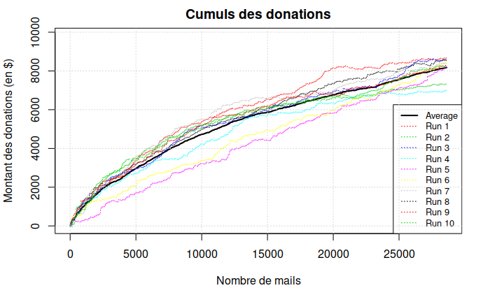

```r
legend('bottomright',
       legend=c('Average', paste('Run', 1:loops)), lwd=c(2, rep(1, loops)),
       lty=c('solid', rep('dotted', loops)), col=1:(loops+1),
       cex=0.8)

grid()
```

Et mettre le tout sous forme de pourcentage.

```r
percentage_results <- sapply(1:(loops+1), function(i) 100 * results[, i] / results[results_rows, i])
index_percentage_results <- 100 * (1:results_rows) / results_rows

plot(index_percentage_results, percentage_results[, loops+1],
     main='Pourcentage des donations',
     xlab='Pourcentage des contacts', ylab='Pourcentage des donations',
     ylim=c(0, percentage_results[results_rows, loops+1]*1.2),
     type='l', lty='solid', lwd=2, col=1)

for(i in 1:loops) {
        lines(index_percentage_results, percentage_results[, i],
              type='l', lty='dotted', lwd=1, col=1+i)
}
```

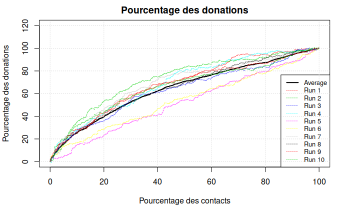

```r
legend('bottomright',
       legend=c('Average', paste('Run', 1:loops)), lwd=c(2, rep(1, loops)),
       lty=c('solid', rep('dotted', loops)), col=1:(loops+1),
       cex=0.8)

grid()
```

## Selecting the Best Tree

On définit l’arbre que l’on connait actuellement comme meilleur arbre et on initialise les meilleurs paramètres connus.

```r
best_tree <- results[,loops+1] + cost * (1:results_rows)

best_minsplit <- 1000
best_minbucket <- 400
best_maxsurrogate <- 4
best_maxdepth <- 10
```

On va par la suite jouer avec les paramètres en commençant ici par la profondeur.

```r
depth_06_tree <- new_tree(10, 0.7, cup98lrn, 1000, 400, 3, 06)[, loops+1]
depth_08_tree <- new_tree(10, 0.7, cup98lrn, 1000, 400, 3, 08)[, loops+1]
depth_12_tree <- new_tree(10, 0.7, cup98lrn, 1000, 400, 3, 12)[, loops+1]
depth_14_tree <- new_tree(10, 0.7, cup98lrn, 1000, 400, 3, 14)[, loops+1]

plot(best_tree,
     main='Cumuls des donations',
     xlab='Nombre de mails', ylab='Montant des donations (en $)',
     ylim=c(0, best_tree[results_rows]*1.2),
     type='l', lty='solid', lwd=2, col=1)

lines(depth_06_tree, type='l', lty='dotted', lwd=1, col=2)
lines(depth_08_tree, type='l', lty='dotted', lwd=1, col=3)
lines(depth_12_tree, type='l', lty='dotted', lwd=1, col=4)
lines(depth_14_tree, type='l', lty='dotted', lwd=1, col=5)

legend('bottomright',
       legend=c(paste('Depth', c(10, 06, 08, 12, 14))), lwd=c(2, rep(1, 4)),
       lty=c('solid', rep('dotted', 4)), col=1:4,
       cex=0.8)

grid()

# On met à jour le meilleur arbre

if(best_tree[results_rows] < depth_06_tree[results_rows]) {
        best_tree <- depth_06_tree
        best_maxdepth <- 06
}
if(best_tree[results_rows] < depth_08_tree[results_rows]) {
        best_tree <- depth_08_tree
        best_maxdepth <- 08
}
if(best_tree[results_rows] < depth_12_tree[results_rows]) {
        best_tree <- depth_12_tree
        best_maxdepth <- 12
}
if(best_tree[results_rows] < depth_14_tree[results_rows]) {
        best_tree <- depth_14_tree
        best_maxdepth <- 14
}
```

On recommence avec maxsurrogate.

```r
surrogate_01_tree <- new_tree(10, 0.7, cup98lrn, 1000, 400, 1, best_maxdepth)[, loops+1]
surrogate_02_tree <- new_tree(10, 0.7, cup98lrn, 1000, 400, 2, best_maxdepth)[, loops+1]
surrogate_03_tree <- new_tree(10, 0.7, cup98lrn, 1000, 400, 3, best_maxdepth)[, loops+1]
surrogate_05_tree <- new_tree(10, 0.7, cup98lrn, 1000, 400, 5, best_maxdepth)[, loops+1]

plot(best_tree,
     main='Cumuls des donations',
     xlab='Nombre de mails', ylab='Montant des donations (en $)',
     ylim=c(0, best_tree[results_rows]*1.2),
     type='l', lty='solid', lwd=2, col=1)

lines(surrogate_01_tree, type='l', lty='dotted', lwd=1, col=2)
lines(surrogate_02_tree, type='l', lty='dotted', lwd=1, col=3)
lines(surrogate_03_tree, type='l', lty='dotted', lwd=1, col=4)
lines(surrogate_05_tree, type='l', lty='dotted', lwd=1, col=5)

legend('bottomright',
       legend=c(paste('Surrogate', c(04, 01, 02, 03, 05))), lwd=c(2, rep(1, 4)),
       lty=c('solid', rep('dotted', 4)), col=1:4,
       cex=0.8)

grid()

# On met à jour le meilleur arbre

if(best_tree[results_rows] < surrogate_01_tree[results_rows]) {
        best_tree <- surrogate_01_tree
        best_maxsurrogate <- 01
}
if(best_tree[results_rows] < surrogate_02_tree[results_rows]) {
        best_tree <- surrogate_02_tree
        best_maxsurrogate <- 02
}
if(best_tree[results_rows] < surrogate_03_tree[results_rows]) {
        best_tree <- surrogate_03_tree
        best_maxsurrogate <- 03
}
if(best_tree[results_rows] < surrogate_05_tree[results_rows]) {
        best_tree <- surrogate_05_tree
        best_maxsurrogate <- 05
}
```

On recommence avec minbucket.

```r
minbucket_200_tree <- new_tree(10, 0.7, cup98lrn, 1000, 200, best_maxsurrogate, best_maxdepth)[, loops+1]
minbucket_300_tree <- new_tree(10, 0.7, cup98lrn, 1000, 300, best_maxsurrogate, best_maxdepth)[, loops+1]
minbucket_500_tree <- new_tree(10, 0.7, cup98lrn, 1000, 500, best_maxsurrogate, best_maxdepth)[, loops+1]
minbucket_600_tree <- new_tree(10, 0.7, cup98lrn, 1000, 600, best_maxsurrogate, best_maxdepth)[, loops+1]

plot(best_tree,
     main='Cumuls des donations',
     xlab='Nombre de mails', ylab='Montant des donations (en $)',
     ylim=c(0, best_tree[results_rows]*1.2),
     type='l', lty='solid', lwd=2, col=1)

lines(minbucket_200_tree, type='l', lty='dotted', lwd=1, col=2)
lines(minbucket_300_tree, type='l', lty='dotted', lwd=1, col=3)
lines(minbucket_500_tree, type='l', lty='dotted', lwd=1, col=4)
lines(minbucket_600_tree, type='l', lty='dotted', lwd=1, col=5)

legend('bottomright',
       legend=c(paste('Minbucket', c(400, 200, 300, 500, 600))), lwd=c(2, rep(1, 4)),
       lty=c('solid', rep('dotted', 4)), col=1:4,
       cex=0.8)

grid()

# On met à jour le meilleur arbre

if(best_tree[results_rows] < minbucket_200_tree[results_rows]) {
        best_tree <- minbucket_200_tree
        best_minbucket <- 200
}
if(best_tree[results_rows] < minbucket_300_tree[results_rows]) {
        best_tree <- minbucket_300_tree
        best_minbucket <- 300
}
if(best_tree[results_rows] < minbucket_500_tree[results_rows]) {
        best_tree <- minbucket_500_tree
        best_minbucket <- 500
}
if(best_tree[results_rows] < minbucket_600_tree[results_rows]) {
        best_tree <- minbucket_600_tree
        best_minbucket <- 600
}
```

On recommence avec minsplit.

```r
minsplit_0600_tree <- new_tree(10, 0.7, cup98lrn, 0600, best_minbucket, best_maxsurrogate, best_maxdepth)[, loops+1]
minsplit_0800_tree <- new_tree(10, 0.7, cup98lrn, 0800, best_minbucket, best_maxsurrogate, best_maxdepth)[, loops+1]
minsplit_1200_tree <- new_tree(10, 0.7, cup98lrn, 1200, best_minbucket, best_maxsurrogate, best_maxdepth)[, loops+1]
minsplit_1400_tree <- new_tree(10, 0.7, cup98lrn, 1400, best_minbucket, best_maxsurrogate, best_maxdepth)[, loops+1]

plot(best_tree,
     main='Cumuls des donations',
     xlab='Nombre de mails', ylab='Montant des donations (en $)',
     ylim=c(0, best_tree[results_rows]*1.2),
     type='l', lty='solid', lwd=2, col=1)

lines(minsplit_0600_tree, type='l', lty='dotted', lwd=1, col=2)
lines(minsplit_0800_tree, type='l', lty='dotted', lwd=1, col=3)
lines(minsplit_1200_tree, type='l', lty='dotted', lwd=1, col=4)
lines(minsplit_1400_tree, type='l', lty='dotted', lwd=1, col=5)

legend('bottomright',
       legend=c(paste('Minbucket', c(1000, 0600, 0800, 1200, 1400))), lwd=c(2, rep(1, 4)),
       lty=c('solid', rep('dotted', 4)), col=1:4,
       cex=0.8)

grid()

# On met à jour le meilleur arbre

if(best_tree[results_rows] < minsplit_0600_tree[results_rows]) {
        best_tree <- minsplit_0600_tree
        best_minbucket <- 0600
}
if(best_tree[results_rows] < minsplit_0800_tree[results_rows]) {
        best_tree <- minsplit_0800_tree
        best_minbucket <- 0800
}
if(best_tree[results_rows] < minsplit_1200_tree[results_rows]) {
        best_tree <- minsplit_1200_tree
        best_minbucket <- 1200
}
if(best_tree[results_rows] < minsplit_1400_tree[results_rows]) {
        best_tree <- minsplit_1400_tree
        best_minbucket <- 1400
}
```

Pour ne pas tuer votre machine, je n’ai pas lancé les 4 codes ci-dessus dans le notebook. Cependant, je les ai testé plusieurs fois sur ma machine et les meilleurs paramètres de controls se sont révélés être :

best_minsplit <- 1000

best_minbucket <- 400

best_maxsurrogate <- 4

best_maxdepth <- 8

## Scoring

Maintenant que nous avons les meilleurs paramètres, on peut charger le meilleur arbre.

```r
load('new_ctree - 1000 - 400 - 4 - 8 - run 10.rdata')
```

On peut ensuite charger le fichier de test cup98val pour y appliquer notre arbre.

```r
cup98val <- read.csv(file='cup98VAL.txt', header=TRUE, sep=',')

cup98val_rows <- nrow(cup98val)
```

Comme précédemment, on se limite aux colonnes intéressantes de cup98val cette fois.

```r
cup98val <- cup98val[c(relevant_col_cup98lrn)] # TARGET_D ne fait pas partie de cup98val
```

```r
vars <- intersect(names(cup98lrn), names(cup98val))

for (i in 1:length(vars)) {
        varname <- vars[i]
        trainLevels <- levels(cup98lrn[, varname])
        scoreLevels <- levels(cup98val[, varname])
        if (is.factor(cup98lrn[, varname]) & setequal(trainLevels, scoreLevels)==F) {
                cat("Warning:new values found in score data, and they will be changed to NA!\n")
                cat(varname, "\n")
                cup98val[, varname] <- factor(cup98val[, varname], levels=trainLevels)
        }
}
```

## Discussions and Conclusions